# AI Module Assignment - Brain Scan Classification

## Setup Environment

```python
%%writefile requirements.txt
numpy
pandas
pydicom
matplotlib
torch
torchvision
torchmetrics
```

```
Overwriting requirements.txt
```

```python
!python -m pip install --upgrade pip
```

```python
!pip install -r requirements.txt
```

```python
import os
import time
import numpy as np
import pandas as pd
import torch
import torch.nn as nn
import torch.optim as optim
from torchvision.datasets import ImageFolder
from torch.utils.data import DataLoader, random_split
from torchvision import transforms
from torchmetrics.classification import Precision, Recall
from torchmetrics import ConfusionMatrix
from PIL import Image
from IPython.display import display, clear_output
```

## Abstract

The NHS has provided a dataset of CT brain scans. These scans indicate the presence of cancer, tumors, or an aneurysm. Differentiating and classifying these conditions requires a trained medical professional. To enhance the efficiency of this process, we propose developing a computer vision model that takes the scan image as input and outputs a classification of the likely affliction faced by the patient.

In this report we explore this process, implementing a convolutional neural network (CNN) and a multi layer perceptron (MLP). We analyse the two, explaining why the CNN outperforms the MLP.

## Introduction

The evolution of medical imaging technologies has enhanced diagnostic capabilities in healthcare, particularly through the use of computed tomography (CT) scans. Accurate and timely interpretation of these scans is critical, as delays can severely impact patient outcomes. However, the complexity of this task demands specialised training, highlighting the necessity for innovative solutions to aid medical professionals.

Recent advancements in artificial intelligence (AI) and machine learning have shown promising potential in medical imaging, particularly through the use of CNNs. In our case we have 84 distinct scans of aneurysms, 91 distinct cancer scans and 84 distinct scans showing tumors. Therefore, we stand to benefit from techniques that can help avoid the limitations of a limited dataset.

This report aims to develop a computer vision model for classifying CT brain scans. It will focus on distinguishing conditions such as tumours and aneurysms. We explore two distinct approaches: a CNN and an MLP. By comparing their performance, we seek to illustrate why the CNN is more effective in this context and develop a model that can perform effectively for this task.

## Dataset Description

The NHS provided our dataset. This includes our image scans for our three classes: aneurysm, cancer and tumor. Each class provides its relevant scan images in it's own folder. For each distinct scan, there are two file types, .dcm and .jpg files. .jpg files are standard images however .dcm files often retain more information from the images such as patient information and imaging parameters. This is known as metadata. For our use case the raw image data obtained from the .jpg will suffice See the table below for more information on the number of files provided in each class.

| Class | Number of Distinct Scans | Total Number of Files |
| --- | --- | --- |
| Aneurysm | 84 | 168 |
| Cancer | 91 | 182 |
| Tumor | 84 | 168 |

See example images from .jpg files below for each class:

#### aneurysm/0.jpg

```python
def display_image(image_path):
    # Open the image
    image = Image.open(image_path)
    # Display the image inline
    display(image)
```

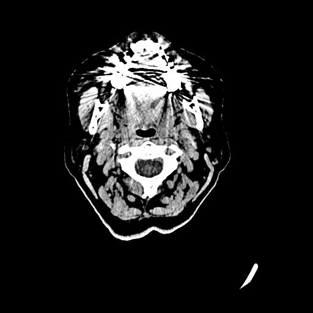

```python
display_image('./data/files/aneurysm/0.jpg')
```

#### cancer/0.jpg

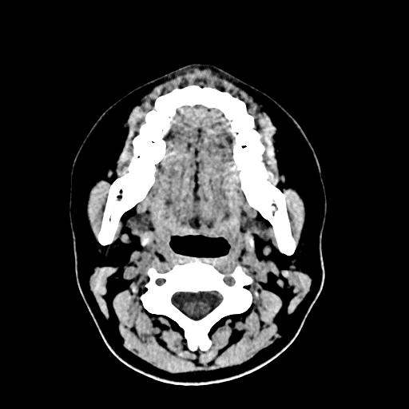

```python
display_image('./data/files/cancer/0.jpg')
```

#### tumor/0.jpg

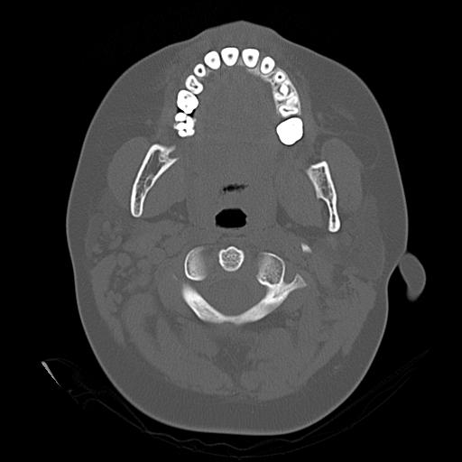

```python
display_image('./data/files/tumor/0.jpg')
```

## Method(s) Explanation

For this report I will take the following steps to achieve the desired outcome:

#### Experimental Setup

- Data Exploration
- Dataset Preparation

#### Methods

##### CNN Model

- Model Setup
- Model Pre-evaluation
- Model Training
- Results

##### MLP Model

- Model Setup
- Model Pre-evaluation
- Model Training
- Results

### Comparison of Results

- Comparing the performance of a CNN to an MLP
- Were the results as expected?

### Discussion

- Why does a CNN outperform an MLP for image classification tasks?
- How would I extend this report?

### Conclusion

- Conclusion

## Experimental Setup

### Data Exploration

First, I explored the dataset. My initial step was to load the directories and view the existing structure for the dataset.

```python
def visualize_folder_structure(path, indent=0, file_limit=10):
    items = os.listdir(path)
    for i, item in enumerate(items):
        if i >= file_limit:
            print("  " * indent + "|-- ...")
            break
        print("  " * indent + "|-- " + item)
        item_path = os.path.join(path, item)
        if os.path.isdir(item_path):
            visualize_folder_structure(item_path, indent + 1, file_limit)

# Example usage
visualize_folder_structure('./data/files')
```

```
|-- aneurysm
  |-- 0.dcm
  |-- 0.jpg
  |-- 1.dcm
  |-- 1.jpg
  |-- 10.dcm
  |-- 10.jpg
  |-- 11.dcm
  |-- 11.jpg
  |-- 12.dcm
  |-- 12.jpg
  |-- ...
|-- cancer
  |-- 0.dcm
  |-- 0.jpg
  |-- 1.dcm
  |-- 1.jpg
  |-- 10.dcm
  |-- 10.jpg
  |-- 11.dcm
  |-- 11.jpg
  |-- 12.dcm
  |-- 12.jpg
  |-- ...
|-- tumor
  |-- 0.dcm
  |-- 0.jpg
  |-- 1.dcm
  |-- 1.jpg
  |-- 10.dcm
  |-- 10.jpg
  |-- 11.dcm
  |-- 11.jpg
  |-- 12.dcm
  |-- 12.jpg
  |-- ...
```

As you can see our classes are simply separated one folder for each file. So we're going to need to split the dataset into training, testing and validation subsets so that we can effectively work with the model. Before doing that we'll need to define any transformations to the model for the training versus the testing and validation. Both sets will need to be resized (larger images means model takes longer to train.) The testing and validation will simply need to be converted to a tensor once it has been resized. Comparatively we may wish to apply data augmentation to the training set to make it more robust.

### Dataset Preparation

Firstly we need to define our transforms as dicsussed.

```python
train_transforms = transforms.Compose([
    transforms.RandomHorizontalFlip(),
    transforms.RandomRotation((45)),
    transforms.Resize((128, 128)),
    transforms.ToTensor(),
])
```

```python
test_val_transforms = transforms.Compose([
    transforms.Resize((128, 128)),
    transforms.ToTensor(),
])
```

Then we can load the dataset. The inbuilt ImageFolder functionality in pytorch will automatically interpret the data directory structure for its labels and ignore the DICOM files.

```python
dataset = ImageFolder("./data/files")
```

As is standard in machine learning we'll then split the dataset into subsets for training validation and testing.

```python
# Define train, testing, and validation splits
train_size = int(0.6 * len(dataset))
val_size = int(0.15 * len(dataset))
test_size = len(dataset) - train_size - val_size
```

```python
# Set the seed and create a generator object with the seed for reproducibility
seed = 123
generator = torch.Generator().manual_seed(seed)
```

```python
# Split dataset
dataset_train, dataset_val, dataset_test = random_split(dataset, [train_size, val_size, test_size], generator=generator)
```

Now we'll apply those transforms and get the dictionary for our class indexes.

```python
# Apply different transforms for train and val/test datasets
dataset_train.dataset.transform = train_transforms
dataset_val.dataset.transform = test_val_transforms
dataset_test.dataset.transform = test_val_transforms
```

```python
# Invert the class_to_idx dictionary to map index to class
idx_to_class = {v: k for k, v in dataset.class_to_idx.items()}
print(idx_to_class)
```

```
{0: 'aneurysm', 1: 'cancer', 2: 'tumor'}
```

Finally, we'll instantiate the data loader objects from our datasets.

```python
# Create dataloaders
dataloader_train = DataLoader(dataset_train, shuffle=True, batch_size=5)
dataloader_val = DataLoader(dataset_val, shuffle=True, batch_size=5)
dataloader_test = DataLoader(dataset_test, shuffle=False, batch_size=5)
```

Let's take a look at some of the examples in our training dataloader.

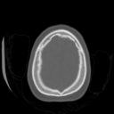

```
tumor
----------
```

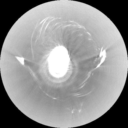

```
aneurysm
----------
```

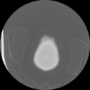

```
tumor
----------
```

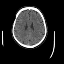

```
aneurysm
----------
```

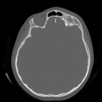

```
tumor
----------
```

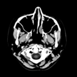

```
cancer
----------
```

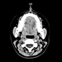

```
cancer
----------
```

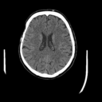

```
aneurysm
----------
```

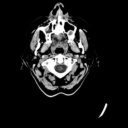

```
aneurysm
----------
```

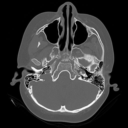

```
tumor
----------
```

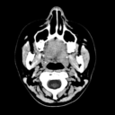

```
cancer
----------
```

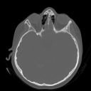

```
tumor
----------
```

[3 more figures not shown]

```
tumor
----------
```

```python
for i, (images, labels) in enumerate(dataloader_train):
    # Limit to 3 sets of 5
    if i >= 3:
        break

    # Process each image in the batch individually
    for idx in range(images.size(0)):
        image = images[idx]
        label = labels[idx]

        # Remove batch dimension and reshape for display
        image_np = image.permute(1, 2, 0).numpy()
        # Scale back to [0, 255] range
        image_np = (image_np * 255).astype('uint8')

        # Convert to PIL and display
        image_pil = Image.fromarray(image_np)
        display(image_pil)
        print(idx_to_class[label.item()])
        print("----------")
```

Now that we've explored and prepared our dataset, let's move on to the methods section of this notebook where I'll implement the CNN and MLP models.

## Methods

### CNN Model

#### Model Setup

A CNN model can be broadly divided into a feature extractor and a classifier for this use case. We use convolutional layers to reduce the complexity of the input image while preserving essential spatial information and local features. Following this, we apply a ReLU activation function to introduce non-linearity, enabling the model to learn more complex patterns. Finally, a MaxPooling layer is used to downsample the feature maps output from the convolution, reducing their dimensionality and computational load while retaining the most important features. This is repeated a few times and then the output is flattened so that it can be fed into the fully connected linear layer for classification.

We'll include some dropout to ensure the network is robust, isn't overly reliant on specific neurons and doesn't overfit.

```python
class CNN(nn.Module):
    def __init__(self, num_classes):
        super().__init__()
        # Define feature extractor
        self.feature_extractor = nn.Sequential(
            nn.Conv2d(3, 32, kernel_size=3, padding=1),
            nn.ReLU(),
            nn.MaxPool2d(kernel_size=2),

            nn.Conv2d(32, 16, kernel_size=3, padding=1),
            nn.ReLU(),
            nn.MaxPool2d(kernel_size=2),

            nn.Conv2d(16, 8, kernel_size=3, padding=1),
            nn.ReLU(),
            nn.MaxPool2d(kernel_size=2),

            nn.Flatten(),
        )
        # Define classifier
        self.classifier = nn.Sequential(
            nn.Dropout(0.5),
            nn.Linear(8 * 16 * 16, num_classes)
        )

    def forward(self, x):
        x = self.feature_extractor(x)
        x = self.classifier(x)
        return x
```

With the architecture built out we'll instantiate the model, the loss criterion and the optimizer.

```python
# Define the model
cnn_net = CNN(num_classes=3)
# Define the loss function
criterion = nn.CrossEntropyLoss()
# Define the optimizer
optimizer = optim.Adam(cnn_net.parameters(), lr=0.001)
```

#### Model Pre-evaluation

Lets evaluate metrics for the model before training.

```python
def evaluate_model(model, dataloader, num_classes=3):
    # Initialize metrics
    metric_precision = Precision(task="multiclass", num_classes=num_classes, average="macro")
    metric_recall = Recall(task="multiclass", num_classes=num_classes, average="macro")
    conf_matrix = ConfusionMatrix(task="multiclass", num_classes=num_classes)

    # Set model to evaluation mode
    model.eval()

    with torch.no_grad():
        for images, labels in dataloader:
            outputs = model(images)
            _, preds = torch.max(outputs, 1)

            # Update metrics
            metric_precision.update(preds, labels)
            metric_recall.update(preds, labels)
            conf_matrix.update(preds, labels)

    # Compute final metrics
    precision = metric_precision.compute()
    recall = metric_recall.compute()
    conf_matrix = conf_matrix.compute()

    return precision, recall, conf_matrix
```

```python
precision, recall, conf_matrix = evaluate_model(cnn_net, dataloader_test)
```

```python
print(f"Precision: {precision}")
print(f"Recall: {recall}")
print(f"Confusion Matrix:\n{conf_matrix}")
```

```
Precision: 0.2222222238779068
Recall: 0.3031401038169861
Confusion Matrix:
tensor([[19,  4,  0],
        [19,  2,  3],
        [19,  0,  0]])
```

Model is basically just guessing. Let's now train it for 10 epochs.

#### Model Training

Below you'll see our training loop. We ensure the model is in training mode. Calculate our loss against the training set and use this to update the parameters. Then we set it to eval mode (meaning the dropout layer isn't active) then calculate its loss against the validation set. We then put it back in training mode and repeat.

```python
def train_model(model, dataloader_train, dataloader_val, criterion, optimizer, num_epochs=5):
    for epoch in range(num_epochs):
        running_loss = 0.0

        # Training phase
        model.train()
        for images, labels in dataloader_train:
            optimizer.zero_grad()
            outputs = model(images)
            loss = criterion(outputs, labels)
            loss.backward()
            optimizer.step()
            running_loss += loss.item()

        epoch_loss = running_loss / len(dataloader_train)

        # Validation phase
        model.eval()
        validation_loss = 0.0
        # Disable gradient calculations
        with torch.no_grad():
            for images, labels in dataloader_val:
                outputs = model(images)
                loss = criterion(outputs, labels)
                validation_loss += loss.item()

        epoch_val_loss = validation_loss / len(dataloader_val)
        print(f"EPOCH {epoch+1} || Training Loss: {epoch_loss:.4f}, Validation Loss: {epoch_val_loss:.4f}")
```

```python
train_model(cnn_net, dataloader_train, dataloader_val, criterion, optimizer, num_epochs=10)
```

```
EPOCH 1 || Training Loss: 0.8620, Validation Loss: 0.3611
EPOCH 2 || Training Loss: 0.5379, Validation Loss: 0.3626
EPOCH 3 || Training Loss: 0.3538, Validation Loss: 0.1128
EPOCH 4 || Training Loss: 0.2336, Validation Loss: 0.0795
EPOCH 5 || Training Loss: 0.1525, Validation Loss: 0.0292
EPOCH 6 || Training Loss: 0.0897, Validation Loss: 0.0187
EPOCH 7 || Training Loss: 0.0675, Validation Loss: 0.0120
EPOCH 8 || Training Loss: 0.0513, Validation Loss: 0.0046
EPOCH 9 || Training Loss: 0.0257, Validation Loss: 0.0066
EPOCH 10 || Training Loss: 0.0660, Validation Loss: 0.0022
```

You should be able to see both the training and validation loss decrease across epochs.

#### Results

Now let's get our metrics using our trained model.

```python
precision, recall, conf_matrix = evaluate_model(cnn_net, dataloader_test)
```

```python
print(f"Precision: {precision}")
print(f"Recall: {recall}")
print(f"Confusion Matrix:\n{conf_matrix}")
```

```
Precision: 0.9523810148239136
Recall: 0.9420289993286133
Confusion Matrix:
tensor([[19,  4,  0],
        [ 0, 24,  0],
        [ 0,  0, 19]])
```

As you can see it performs really well, we'll discuss this in the results. (Remember to save the model.)

```python
# Save the model's state_dict
torch.save(cnn_net.state_dict(), "CustomCNN.pth")
```

### MLP Model

#### Model Setup

The MLP model begins by flattening the input image into a one-dimensional vector, as MLPs are designed to process vectorised data and do not retain spatial relationships.

The first fully connected layer reduces the dimensionality of the input, transforming it into a smaller and more computationally efficient size. A ReLU activation function is applied to introduce non-linearity, enabling the model to identify and learn complex patterns within the data. The second fully connected layer then maps these extracted features to the predefined output classes otherwise known as classification.

To enhance the model’s robustness and reduce the risk of overfitting, a dropout layer is incorporated during training for the same reasons we did in the CNN.

```python
# Define the MLP Model
class MLP(nn.Module):
    def __init__(self, num_classes):
        super(MLP, self).__init__()
        self.flatten = nn.Flatten()
        self.fc1 = nn.Linear(128*128*3, 8)
        self.fc2 = nn.Linear(8, num_classes)
        self.relu = nn.ReLU()
        self.dropout = nn.Dropout(p=0.5)

    def forward(self, x):
        x = self.flatten(x)
        x = self.relu(self.fc1(x))
        x = self.fc2(x)
        x = self.dropout(x)
        return x
```

As usual we'll instantiate our model, loss criterion and optimizer.

```python
mlp_net = MLP(3)
```

```python
criterion = nn.CrossEntropyLoss()
optimizer = optim.Adam(mlp_net.parameters(), lr=0.001)
```

#### Model Pre-evalutation

We'll again evaluate our metrics prior to testing to ensure no funny business.

```python
precision, recall, conf_matrix = evaluate_model(mlp_net, dataloader_test)
```

```python
print(f"Precision: {precision}")
print(f"Recall: {recall}")
print(f"Confusion Matrix:\n{conf_matrix}")
```

```
Precision: 0.11616161465644836
Recall: 0.3333333432674408
Confusion Matrix:
tensor([[23,  0,  0],
        [24,  0,  0],
        [19,  0,  0]])
```

Again, the model before training is effectiviely guessing.

#### Model Training

We'll train the model again using the same type of training loop.

```python
train_model(mlp_net, dataloader_train, dataloader_val, criterion, optimizer, num_epochs=10)
```

```
EPOCH 1 || Training Loss: 1.5052, Validation Loss: 0.7322
EPOCH 2 || Training Loss: 1.1033, Validation Loss: 0.6831
EPOCH 3 || Training Loss: 0.8534, Validation Loss: 0.4020
EPOCH 4 || Training Loss: 0.6911, Validation Loss: 0.3217
EPOCH 5 || Training Loss: 0.5849, Validation Loss: 0.2965
EPOCH 6 || Training Loss: 0.5883, Validation Loss: 0.1877
EPOCH 7 || Training Loss: 0.7464, Validation Loss: 0.4469
EPOCH 8 || Training Loss: 0.7051, Validation Loss: 0.4757
EPOCH 9 || Training Loss: 0.6502, Validation Loss: 0.4108
EPOCH 10 || Training Loss: 0.6236, Validation Loss: 0.4117
```

As you can see in this case the validation loss seems to plateau and the decrease in training loss is less. This simply indicates it is harder for this network to learn.

#### Results

Now let's get our metrics using our trained model.

```python
precision, recall, conf_matrix = evaluate_model(mlp_net, dataloader_test)
```

```python
print(f"Precision: {precision}")
print(f"Recall: {recall}")
print(f"Confusion Matrix:\n{conf_matrix}")
```

```
Precision: 0.5158730149269104
Recall: 0.6666666865348816
Confusion Matrix:
tensor([[23,  0,  0],
        [ 0, 24,  0],
        [19,  0,  0]])
```

It's actually done suprisingly well, but still quite poor in comparsion to our CNN. (Remember to save.) In the next part of this notebook we'll compare these results and then move on to why the disparity in performance in the discussion.

```python
# Save the model's state_dict
torch.save(mlp_net.state_dict(), "CustomMLP.pth")
```

## Comparison of Results

Before comparing the results let's compare the models. The architectural differences are obvious but let's take a look at the parameters.

```python
def count_parameters(model):
    return sum(p.numel() for p in model.parameters() if p.requires_grad)
```

```python
total_params = count_parameters(mlp_net)
print(f"'mlp_net': Total trainable parameters: {total_params}")
```

```
'mlp_net': Total trainable parameters: 393251
```

```python
total_params = count_parameters(cnn_net)
print(f"'cnn_net': Total trainable parameters: {total_params}")
```

```
'cnn_net': Total trainable parameters: 12827
```

Even with over 30x the trainable parameters, the MLP model still performs significantly worse than the CNN model. We'll address why in the discussion but this is worth noting now.

The CNN achieved a result of 95% precision and 94% recall on the testing dataset. This indicates that the model has been well trained. It's unlikely that this is due to overfitting due to the high level of dropout, the comparatively low level of parameters and the fact that the test data was entirely unseen during training.

Comparatively the MLP achieves 52% precision and 66% recall. From the confusion matrix we can see clearly that it's issue is being able to distingusih aneurysm scans from tumours. It seems to lump these two categories together as aneurysm. This is likely due to the fact that it is unable to distinguish features whereas the CNN can achieve this through its convolutional layers. This is a key point we will touch on in the discussion. (If we reran this we'd likely see different categories lumped together depending on the weights the models are initialised with.)

Overall the results were exactly as expexted. The only suprises were quite how well both models performed. This is likely due to a small and easy to interpret testing dataset.

## Discussion

**So why does a CNN model generally outperform an MLP model?**

"The distinction of CNN from a “plain” multilayer perceptron (MLP) network is its usage of convolutional layers, pooling, and non-linearities such as tanh, sigmoid, and ReLU." Agarap, A.F.M. (2017)

The quote above underscores a key limitation of MLPs: their fully connected layers are too simplistic to process complex patterns effectively. In contrast, CNNs use convolutional filters that slide over input images, enabling downsampling while preserving and capturing essential features. As this filter (sometimes known as a window) is limited to specific areas of the image it identifies "local" features specifically.  
This approach allows CNNs to excel in tasks like image classification, as they understand spatial hierarchies and these local patterns more efficiently. Additionally, their downsampling reduces computational complexity, making them more scalable for larger datasets and deeper architectures.

**How would I extend this report?**

I'd also like to do some hyperparameter tuning. I used a pretty standard learning rate of 0.001 but there may be a more optimal value.  
Additionally, I could do some sensitivity testing on the performance of my models dependent on the training, validation and testing split. I found through trial and error that having a larger testing split was required for more accurate metrics due to the dataset being small but it would have been good to programmatically confirm this.

## Conclusion

This report examines the development and evaluation of deep learning, computer vision models to classify CT brain scans into aneurysm, cancer, and tumor categories. Two approaches were implemented and compared: a Convolutional Neural Network (CNN) and a Multi-Layer Perceptron (MLP).

The CNN’s downsampling preserves critical features while reducing computational complexity making it better suited to larger datasets and deeper architectures. Despite having more trainable parameters, the MLP could not match the CNN’s accuracy. this highlights the importance of model architecture.

Future improvements could include expanding the dataset through artificial data generation. This would address small dataset limitations.

In summary, this report highlights the effectiveness of CNNs for medical image classification and demonstrates the potential of AI to support medical professionals in diagnosing conditions.

## Code Availability

This report is provided as a zip file containing both the html export of this jupyter notebook and the jupyter notebook itself.

Please keep in mind when running the jupyter notebook, the exact results from the training will differ and hence the exact values presented in the comparison of results and conclusion will differ.

## References

Agarap, A.F.M. (2017). Comparing the Performance of CNN and MLP in Image Classification. [online] Available at: https://a-damle.com/project_files/mlp_vs_cnn/mlp_vs_cnn.pdf [Accessed: 22/01/25].

Zaitian Wang et al. (2024). Data Augmentation using Large Language Models: Data Perspectives, Learning Paradigms and Challenges. arXiv. Available at: https://arxiv.org/pdf/2405.09591 [Accessed: 22/01/25].